# Project 2 Writeup

Team 7

2024-12-12

#Read in dataset#

```r
housing_data <- read.csv("housingdata.csv")
```

#Summarize the most important parts of EDA here#

From our EDA before, we found the ZHVI to continuously go up year by year for every region in the DMV except for D.C. in between years 2022-2023. Homes in the areas were most expensive in D.C. then Maryland, and then Virginia.

Statistical testing confirmed that the difference in ZHVIs between the three regions were significant throughout the 3 years we worked with.

We also did statistical testing on each region year by year. The result was the difference in ZHVI for D.C. throughout all three years was not statistically significant. The changes in ZHVI for D.C. were not as heavy as both MD and VA. Statistical testing for MD revealed the difference in ZHVI in just Maryland between 2021-2023 was statistically significant. The same result for VA.

#Modeling work#

```r
library(ggplot2)
#revisit the data
str(housing_data)
```

```
## 'data.frame':    43308 obs. of  9 variables:
##  $ RegionID  : int  67182 67732 67180 66126 66705 66843 67730 66135 67010 66683 ...
##  $ SizeRank  : int  80 140 165 174 199 268 275 277 321 322 ...
##  $ RegionName: int  22193 23464 22191 20002 20906 21234 23462 20011 21740 20878 ...
##  $ RegionType: chr  "zip" "zip" "zip" "zip" ...
##  $ State     : chr  "VA" "VA" "VA" "DC" ...
##  $ City      : chr  "Woodbridge" "Virginia Beach" "Woodbridge" "Washington" ...
##  $ Metro     : chr  "Washington-Arlington-Alexandria, DC-VA-MD-WV" "Virginia Beach-Norfolk-Newport News, VA-NC" "Washington-Arlington-Alexandria, DC-VA-MD-WV" "Washington-Arlington-Alexandria, DC-VA-MD-WV" ...
##  $ month     : chr  "2021-01-31" "2021-01-31" "2021-01-31" "2021-01-31" ...
##  $ ZHVI      : num  382710 298449 368262 671416 380993 ...
```

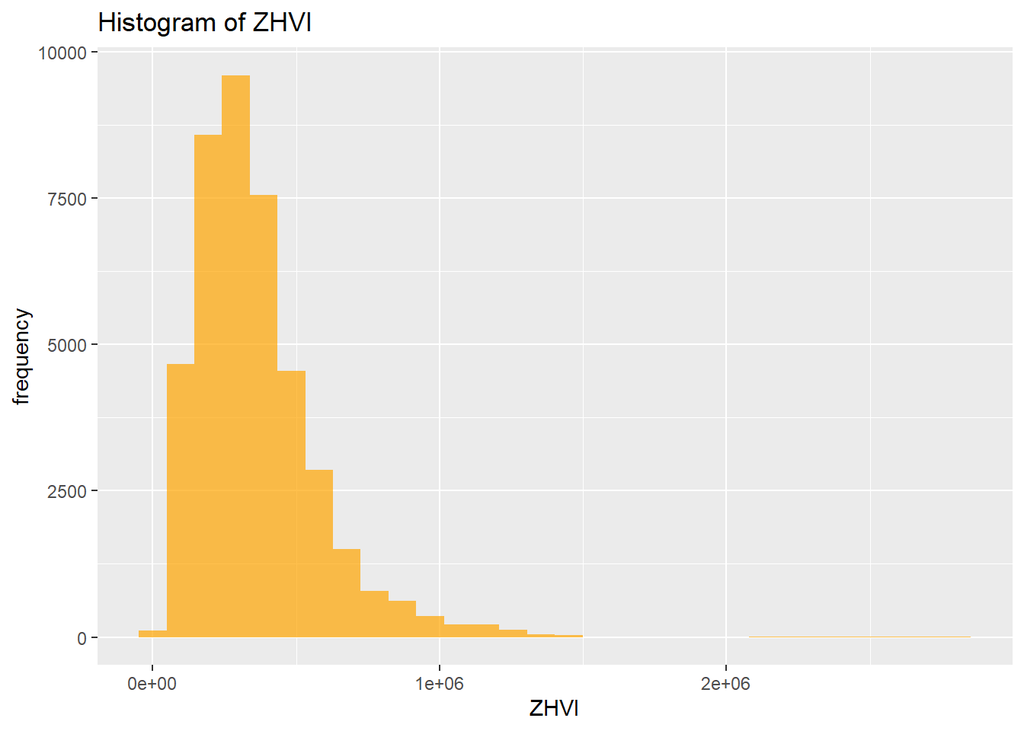

```r
ggplot(housing_data, aes(x = ZHVI)) +
  geom_histogram(bins = 30, fill = "orange", alpha= 0.7) +
  labs(title = "Histogram of ZHVI", x = "ZHVI", y = "frequency")
```

The target variable in our models, ZHVI, doesn’t look normally distributed so before moving forward with modeling it’s best to transform it to have it be as normally distributed as possible. We will do that below.

#Creating log transformed ZHVI#

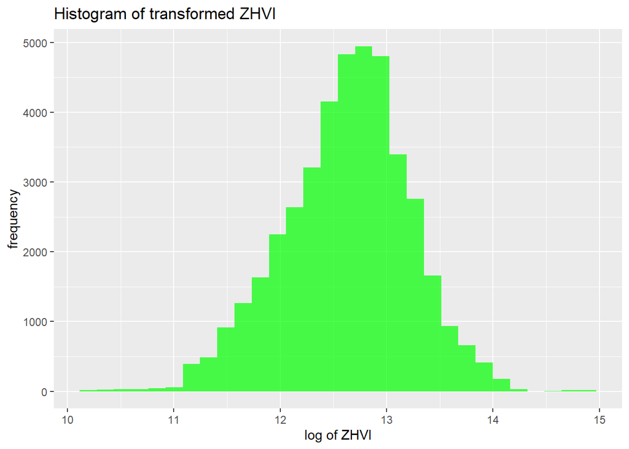

```r
#Create a new column for log transformed ZHVI
housing_data$log_of_ZHVI <- log(housing_data$ZHVI)


library(ggplot2)
#Result is something that looks more normally distributed
ggplot(housing_data, aes(x = log_of_ZHVI))+
  geom_histogram(bins = 30, fill = 'green', alpha = 0.7) +
  labs(title = 'Histogram of transformed ZHVI', x = 'log of ZHVI', y = 'frequency')
```

After transforming the target variable, we can observe that the variable isn’t perfectly distributed, but it’s taken a large step in coming as close as possible to being normally distributed as possible. Therefore, we will move forward with the transformation being our target variable in future models.

#Preparing predictors to work in models#

```r
#Creating a year variable and making it numeric
housing_data$year <- substr(housing_data$month, 1, 4)
housing_data$year <- as.numeric(housing_data$year)

#Changing the categorical variables in our data to factors
housing_data$RegionName <- as.factor(housing_data$RegionName)
housing_data$State <- as.factor(housing_data$State)
housing_data$Metro <- as.factor(housing_data$Metro)
housing_data$City <- as.factor(housing_data$City)

#Renaming RegionName to Zipcode since that's what the values of the variable are
colnames(housing_data)[colnames(housing_data) == "RegionName"] <-"Zipcode"

#Check the results and levels to factoring and renaming
summary(housing_data)
```

```
##     RegionID         SizeRank        Zipcode       RegionType        State
##  Min.   : 66125   Min.   :   80   20001  :   36   Length:43308       DC:  792
##  1st Qu.: 66825   1st Qu.: 6391   20002  :   36   Class :character   MD:15228
##  Median : 67339   Median :13358   20003  :   36   Mode  :character   VA:27288
##  Mean   : 67591   Mean   :13672   20004  :   36
##  3rd Qu.: 67835   3rd Qu.:20293   20005  :   36
##  Max.   :399556   Max.   :39992   20006  :   36
##                                   (Other):43092
##              City                                                Metro
##  Washington    :  828   Washington-Arlington-Alexandria, DC-VA-MD-WV:11052
##  Baltimore     :  720                                               : 9144
##                :  540   Baltimore-Columbia-Towson, MD               : 5292
##  Norfolk       :  432   Richmond, VA                                : 3024
##  Arlington     :  360   Virginia Beach-Norfolk-Newport News, VA-NC  : 2988
##  Virginia Beach:  324   Charlottesville, VA                         : 1224
##  (Other)       :40104   (Other)                                     :10584
##     month                ZHVI          log_of_ZHVI         year
##  Length:43308       Min.   :  25919   Min.   :10.16   Min.   :2021
##  Class :character   1st Qu.: 209760   1st Qu.:12.25   1st Qu.:2021
##  Mode  :character   Median : 316930   Median :12.67   Median :2022
##                     Mean   : 358347   Mean   :12.62   Mean   :2022
##                     3rd Qu.: 448365   3rd Qu.:13.01   3rd Qu.:2023
##                     Max.   :2829491   Max.   :14.86   Max.   :2023
##                     NA's   :1496      NA's   :1496
```

```r
str(housing_data)
```

```
## 'data.frame':    43308 obs. of  11 variables:
##  $ RegionID   : int  67182 67732 67180 66126 66705 66843 67730 66135 67010 66683 ...
##  $ SizeRank   : int  80 140 165 174 199 268 275 277 321 322 ...
##  $ Zipcode    : Factor w/ 1203 levels "20001","20002",..: 524 844 522 2 213 318 843 11 415 201 ...
##  $ RegionType : chr  "zip" "zip" "zip" "zip" ...
##  $ State      : Factor w/ 3 levels "DC","MD","VA": 3 3 3 1 2 2 3 1 2 2 ...
##  $ City       : Factor w/ 871 levels "","Abell","Aberdeen",..: 861 813 861 824 723 602 813 824 372 325 ...
##  $ Metro      : Factor w/ 24 levels "","Baltimore-Columbia-Towson, MD",..: 23 22 23 23 23 2 22 23 12 23 ...
##  $ month      : chr  "2021-01-31" "2021-01-31" "2021-01-31" "2021-01-31" ...
##  $ ZHVI       : num  382710 298449 368262 671416 380993 ...
##  $ log_of_ZHVI: num  12.9 12.6 12.8 13.4 12.9 ...
##  $ year       : num  2021 2021 2021 2021 2021 ...
```

Many of our variables are categorical (not ordinal) variables. We will further discuss the impact this will have later, but for now let’s convert these variables to factors of varying levels. The dataset, from Zillow, is mostly comprised of geographical variables of different levels(State, metro area, city, zip code). By levels I mean each variable is a more specific representation than the last. Like how city and states could possibly represent a similar area or have overlap, but city is a more focused area geographically.

To summarize some key findings we have 43,308 observations with 11 variables now that we’ve added log of ZHVI and year as variables. Many of the variables we converted into factors have high levels. Namely Zipcode and City. We will later discuss why that isn’t good for some of our models later.

With the initial model we’ve built included the changed variables like state, metro, city, and Zipcode into factor variables. Our first model is testing what we might find from most of the variables being included in the linear model. Kind of like backward stepwise feature selection except we aren’t including variables like city which we tested on our own time. We left it out of a chunk because it made knitting slow.

Based on what we know about these variables, it would be counterintuitive to include all variables since again many of them are geographic. The result could give us multicollinearity and will definetely result in overfitting since the model will be introduced to noise. Not only that, but the computation for the model is quite extensive at least using a laptop it is.

The result for the model with Zipcode is a model that’s very over fitting. With a multiple and adjusted R-squared of 0.996 as well as a residual standard error of 0.0393.

For the second model where we replaced Zipcode with the variable City instead. The reasoning was simply because City had fewer levels than Zipcode. Here we observed a multiple R-squared of 0.9299 and an adjusted R-squared of 0.9283. For this model, it’s worth double checking and testing overfitting. We excluded it from our presentation for the sake of the audience’s ability to interpret it and model complexity. We also tested overfitting for that too, but again the knitting froze when including those code chunks.

#Simple Model 1 - Linear Regression without City or Zipcode#

```r
#Avoiding factor variables with a large number of levels
ZHVI_model_simple <- lm(log_of_ZHVI ~ year + State + Metro + SizeRank, data = housing_data)
summary(ZHVI_model_simple)
```

```
##
## Call:
## lm(formula = log_of_ZHVI ~ year + State + Metro + SizeRank, data = housing_data)
##
## Residuals:
##      Min       1Q   Median       3Q      Max
## -2.03518 -0.22239  0.01629  0.23090  1.98074
##
## Coefficients:
##                                                     Estimate Std. Error t value
## (Intercept)                                       -1.024e+02  4.665e+00 -21.957
## year                                               5.674e-02  2.307e-03  24.593
## StateMD                                           -1.659e-01  1.464e-02 -11.332
## StateVA                                           -1.309e-01  1.454e-02  -9.001
## MetroBaltimore-Columbia-Towson, MD                 7.785e-01  9.322e-03  83.507
## MetroBig Stone Gap, VA                            -7.634e-01  2.458e-02 -31.053
## MetroBlacksburg-Christiansburg, VA                 2.985e-02  1.570e-02   1.901
## MetroBluefield, WV-VA                             -4.953e-01  1.825e-02 -27.137
## MetroCalifornia-Lexington Park, MD                 7.648e-01  1.569e-02  48.737
## MetroCambridge, MD                                 2.842e-01  2.136e-02  13.303
## MetroCharlottesville, VA                           5.174e-01  1.178e-02  43.932
## MetroCumberland, MD-WV                            -2.731e-01  2.126e-02 -12.846
## MetroDanville, VA                                 -3.560e-01  1.656e-02 -21.501
## MetroEaston, MD                                    1.070e+00  1.906e-02  56.161
## MetroHagerstown-Martinsburg, MD-WV                 4.673e-01  1.847e-02  25.309
## MetroHarrisonburg, VA                              4.225e-01  1.790e-02  23.604
## MetroKingsport-Bristol, TN-VA                     -1.913e-01  1.708e-02 -11.198
## MetroLynchburg, VA                                 1.396e-01  1.334e-02  10.467
## MetroMartinsville, VA                             -5.996e-01  2.461e-02 -24.368
## MetroPhiladelphia-Camden-Wilmington, PA-NJ-DE-MD   5.454e-01  1.944e-02  28.059
## MetroRichmond, VA                                  4.586e-01  8.485e-03  54.046
## MetroRoanoke, VA                                   2.066e-01  1.253e-02  16.493
## MetroSalisbury, MD-DE                              2.172e-01  1.404e-02  15.470
## MetroStaunton, VA                                  3.715e-01  1.530e-02  24.283
## MetroVirginia Beach-Norfolk-Newport News, VA-NC    3.865e-01  8.510e-03  45.415
## MetroWashington-Arlington-Alexandria, DC-VA-MD-WV  1.022e+00  6.507e-03 157.015
## MetroWinchester, VA-WV                             6.312e-01  2.074e-02  30.440
## SizeRank                                          -1.431e-06  2.560e-07  -5.591
##                                                   Pr(>|t|)
## (Intercept)                                        < 2e-16 ***
```

[output cut: 19 more lines]

```
## MetroRichmond, VA                                  < 2e-16 ***
## MetroRoanoke, VA                                   < 2e-16 ***
## MetroSalisbury, MD-DE                              < 2e-16 ***
## MetroStaunton, VA                                  < 2e-16 ***
## MetroVirginia Beach-Norfolk-Newport News, VA-NC    < 2e-16 ***
## MetroWashington-Arlington-Alexandria, DC-VA-MD-WV  < 2e-16 ***
## MetroWinchester, VA-WV                             < 2e-16 ***
## SizeRank                                          2.28e-08 ***
## ---
## Signif. codes:  0 '***' 0.001 '**' 0.01 '*' 0.05 '.' 0.1 ' ' 1
##
## Residual standard error: 0.3837 on 41784 degrees of freedom
##   (1496 observations deleted due to missingness)
## Multiple R-squared:  0.5758, Adjusted R-squared:  0.5755
## F-statistic:  2101 on 27 and 41784 DF,  p-value: < 2.2e-16
```

After simplifying the model by removing RegionName(zipcode) we see that the r-squared has dropped significantly to 0.576 and the adjusted r-squared is now 0.576. We believe we can build a model with a stronger predictive power. We also decided to check if maybe we can achieve so by using interactions. The downside is building a model with interaction can lead to more difficulty in interpretation and a higher complexity. Therefore, we have to decide if the trade-off is worth it. We will do so in the next code chunk.

#Check model with the same variables, this time adding interactions#

```r
#Model this time showing interactions between year and state, year and metro, sizerank and metro
ZHVI_model_interaction <- lm(log_of_ZHVI ~ year * State + year * Metro + SizeRank * Metro, data = housing_data)
summary(ZHVI_model_interaction)
```

```
##
## Call:
## lm(formula = log_of_ZHVI ~ year * State + year * Metro + SizeRank *
##     Metro, data = housing_data)
##
## Residuals:
##      Min       1Q   Median       3Q      Max
## -2.00964 -0.22603  0.01349  0.22382  1.55933
##
## Coefficients:
##                                                              Estimate
## (Intercept)                                                 7.654e+00
## year                                                        2.325e-03
## StateMD                                                    -9.614e+01
## StateVA                                                    -1.063e+02
## MetroBaltimore-Columbia-Towson, MD                          2.552e+01
## MetroBig Stone Gap, VA                                     -4.218e+01
## MetroBlacksburg-Christiansburg, VA                         -1.634e+01
## MetroBluefield, WV-VA                                      -6.590e+00
## MetroCalifornia-Lexington Park, MD                          3.818e+01
## MetroCambridge, MD                                          9.152e+01
## MetroCharlottesville, VA                                   -4.039e+01
## MetroCumberland, MD-WV                                     -2.496e+01
## MetroDanville, VA                                          -6.245e+01
## MetroEaston, MD                                             1.950e+01
## MetroHagerstown-Martinsburg, MD-WV                         -2.946e-02
## MetroHarrisonburg, VA                                      -3.497e+01
## MetroKingsport-Bristol, TN-VA                              -9.798e+01
## MetroLynchburg, VA                                         -5.965e+01
## MetroMartinsville, VA                                      -9.532e+01
## MetroPhiladelphia-Camden-Wilmington, PA-NJ-DE-MD            2.583e+01
## MetroRichmond, VA                                          -5.724e+01
## MetroRoanoke, VA                                           -5.044e+01
## MetroSalisbury, MD-DE                                      -3.304e+01
## MetroStaunton, VA                                           4.522e+00
## MetroVirginia Beach-Norfolk-Newport News, VA-NC            -3.280e+01
## MetroWashington-Arlington-Alexandria, DC-VA-MD-WV           1.032e+01
## MetroWinchester, VA-WV                                     -2.366e+01
## SizeRank                                                   -5.765e-06
## year:StateMD                                                4.747e-02
```

[output cut: 193 more lines]

```
## MetroPhiladelphia-Camden-Wilmington, PA-NJ-DE-MD:SizeRank  0.106414
## MetroRichmond, VA:SizeRank                                 0.023480 *
## MetroRoanoke, VA:SizeRank                                   < 2e-16 ***
## MetroSalisbury, MD-DE:SizeRank                             5.10e-06 ***
## MetroStaunton, VA:SizeRank                                 0.770836
## MetroVirginia Beach-Norfolk-Newport News, VA-NC:SizeRank   0.267457
## MetroWashington-Arlington-Alexandria, DC-VA-MD-WV:SizeRank 0.871761
## MetroWinchester, VA-WV:SizeRank                            2.30e-05 ***
## ---
## Signif. codes:  0 '***' 0.001 '**' 0.01 '*' 0.05 '.' 0.1 ' ' 1
##
## Residual standard error: 0.3718 on 41736 degrees of freedom
##   (1496 observations deleted due to missingness)
## Multiple R-squared:  0.6022, Adjusted R-squared:  0.6015
## F-statistic: 842.6 on 75 and 41736 DF,  p-value: < 2.2e-16
```

From checking the interaction between predictors like year and state or year and metro among other interactions. The new model explains slightly more variance in the data (60.2%). However the adjusted r squared is slightly lower than the multiple r squared meaning we’re still being punished for some redundancy or uneeded predictors. We still believe there’s room for improvement though.

Conclusions from interactions:

Year does not have a significant impact on ZHVI on it’s own. Of course this is to be expected since year doesn’t have the same uniform affect across all areas. (Coefficient=2.33e-03, p= 0.89596)

As discussed before, compared to DC states MD and VA have negative effects on ZHVI. Of course metro terms are significant signaling year has a different impact on different metro areas.

With that being said, we want to move forward by keeping the model as simple as possible. We decide that the trade-off between having interaction terms and the increase of our multiple and adjusted r-squared values isn’t worth it. We move foward with the linear regression model from before that didn’t have interaction terms.

Before moving forward with the initial simple model without interaction terms, we will check the assumptions of linear regression model are satisfied with the simple model.

#Checking assumptions of linear regression models from our initial model with 4 predictors no interactions#

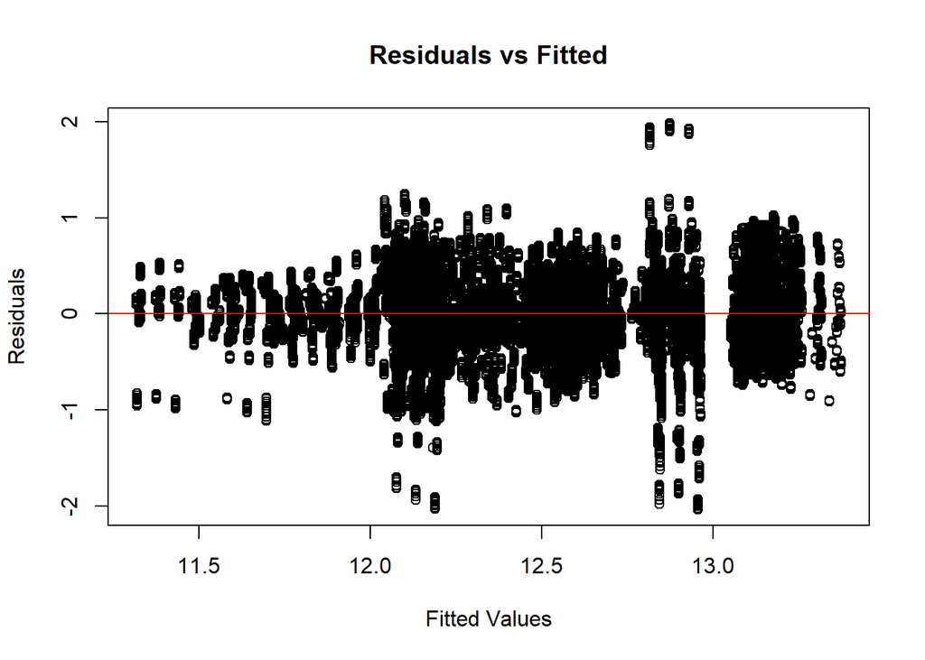

```r
#Checking residuals, normality, homoscedasticity

# Residuals vs. Fitted Values Plot
plot(ZHVI_model_simple$fitted.values, resid(ZHVI_model_simple),
     xlab = "Fitted Values", ylab = "Residuals",
     main = "Residuals vs Fitted")
abline(h = 0, col = "red")
```

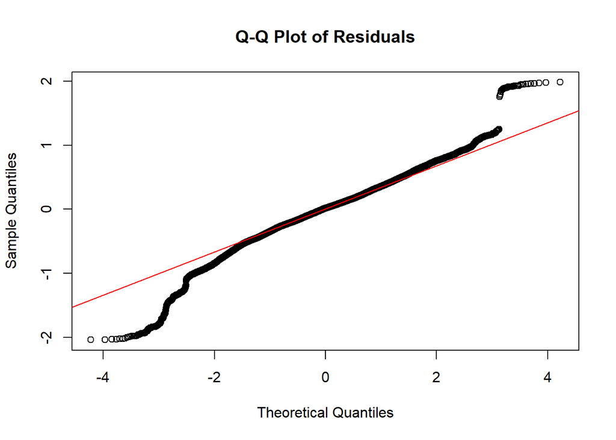

```r
# Q-Q Plot for Normality of Residuals
qqnorm(resid(ZHVI_model_simple), main = "Q-Q Plot of Residuals")
qqline(resid(ZHVI_model_simple), col = "red")
```

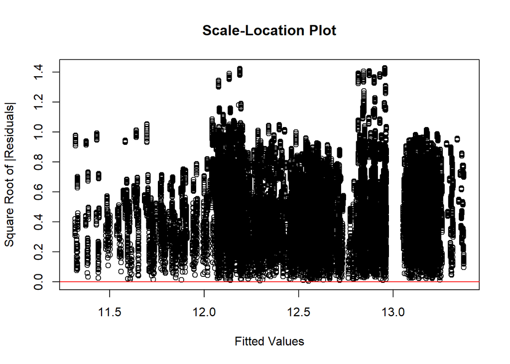

```r
# Scale-Location Plot
plot(ZHVI_model_simple$fitted.values, sqrt(abs(resid(ZHVI_model_simple))),
     xlab = "Fitted Values", ylab = "Square Root of |Residuals|",
     main = "Scale-Location Plot")
abline(h = 0, col = "red")
```

```r
#Check normality
ks.test(resid(ZHVI_model_simple), "pnorm",
        mean = mean(resid(ZHVI_model_simple)),
        sd = sd(resid(ZHVI_model_simple)))
```

```
##
##  Asymptotic one-sample Kolmogorov-Smirnov test
##
## data:  resid(ZHVI_model_simple)
## D = 0.0353, p-value < 2.2e-16
## alternative hypothesis: two-sided
```

```r
#Check Homoscedasticity
library(lmtest)
bptest(ZHVI_model_simple)
```

```
##
##  studentized Breusch-Pagan test
##
## data:  ZHVI_model_simple
## BP = 3152.5, df = 27, p-value < 2.2e-16
```

From the Asymptotic one sample kolmogorov-smirnov test we can see the test statistic is very low which indicates we’re very close to normal distribution which is good. However the p value says the residuals don’t follow a normal distribution. This could be due to a number of outliers in the dataset.

Following the residuals vs fitted plot and the q-q plot, we observe there is some heteroscedasticity. The q-q plot also shows there are a few outliers in the dataset.

This is to be expected since ZHVI was not normally distributed. Taking the log transformation of ZHVI helped, but didn’t make it perfectly normally distributed. Let’s check the mutlicollinearity.

#Checking simple linear regression model for collinearity#

```r
#Checking for Multicollinearity
library(car)
vif(ZHVI_model_simple)
```

```
##              GVIF Df GVIF^(1/(2*Df))
## year     1.001465  1        1.000732
## State    3.059278  2        1.322528
## Metro    3.813682 23        1.029527
## SizeRank 1.280740  1        1.131698
```

Based on the output of the vif stats, we observe that the VIF for all variables is below 5 and is acceptable. We can move forward with adjusting the model based on this. Let us try and test the model by splitting the data by our newly created variable, year. We will train our data on the years 2021 and 2022 and test it on the year 2023.

#Testing and plotting results for simple linear regression#

```r
#Split into training and testing by year
training_data <- subset(housing_data, year %in% c(2021, 2022))
testing_data <- subset(housing_data, year == 2023)

ZHVI_model_train <- lm(log_of_ZHVI ~ year + State + Metro + SizeRank, data = training_data)


predictions <- predict(ZHVI_model_train, newdata = testing_data)
valid_actuals<- testing_data$log_of_ZHVI


# Filter to only include rows with non-missing valid_actuals
valid_data <- data.frame(actuals = valid_actuals, predictions = predictions)
valid_data <- valid_data[!is.na(valid_data$actuals), ]

# Extract filtered actuals and predictions
valid_actuals <- valid_data$actuals
predictions <- valid_data$predictions


# Now calculate performance metrics
valid_residuals <- valid_actuals - predictions

MAE <- mean(abs(valid_residuals))   # Mean Absolute Error
RMSE <- sqrt(mean(valid_residuals^2)) # Root Mean Squared Error
R2 <- cor(predictions, valid_actuals)^2  # R-squared

cat("MAE:", MAE, "\n")
```

```
## MAE: 0.2925366
```

```r
cat("RMSE:", RMSE, "\n")
```

```
## RMSE: 0.3897215
```

```r
cat("R-squared:", R2, "\n")
```

```
## R-squared: 0.5609587
```

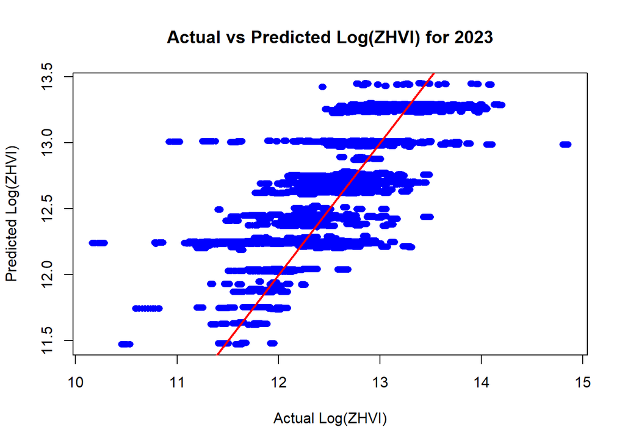

```r
#Scatter plot
plot(
  valid_actuals, predictions,
  xlab = "Actual Log(ZHVI)", ylab = "Predicted Log(ZHVI)",
  main = "Actual vs Predicted Log(ZHVI) for 2023",
  pch = 16, col = "blue"
)
abline(0, 1, col = "red", lwd = 2) # Add a 45-degree line for perfect prediction
```

To fully test how our model performs on unseen data, we decided to split the data into training and testing sets based on years as mentioned before. As shown above, we gave the years 2021-2022 into the training set and 2023 into the test set to observe how well our model will work on unseen data. The result is the model explains 56% of the variance in log(ZHVI) with a MAE of 0.293 and RMSE of 0.39.

The results suggest that housing data in the real world can be very complex. Things like income, housing supply, household size, crime, and more were not included in the data Zillow provides from their website directly. This could explain the plateu we’re witnessing when adding more variables from what we presently have. It’s worth testing whether or not other models can perform better. Models that don’t require some of the assumptions that were a bit tested in our dataset.

#Trying GLS modeling#

```r
#Doing GLS modeling
library(nlme)
housing_data_clean<- na.omit(housing_data)


ZHVI_gls_model <- gls(log_of_ZHVI ~ year + State + Metro + SizeRank, data = housing_data_clean)

summary(ZHVI_gls_model)
```

```
## Generalized least squares fit by REML
##   Model: log_of_ZHVI ~ year + State + Metro + SizeRank
##   Data: housing_data_clean
##        AIC      BIC    logLik
##   38808.36 39058.93 -19375.18
##
## Coefficients:
##                                                        Value Std.Error
## (Intercept)                                       -102.43463  4.665187
## year                                                 0.05674  0.002307
## StateMD                                             -0.16593  0.014643
## StateVA                                             -0.13086  0.014540
## MetroBaltimore-Columbia-Towson, MD                   0.77848  0.009322
## MetroBig Stone Gap, VA                              -0.76339  0.024584
## MetroBlacksburg-Christiansburg, VA                   0.02985  0.015705
## MetroBluefield, WV-VA                               -0.49529  0.018251
## MetroCalifornia-Lexington Park, MD                   0.76475  0.015692
## MetroCambridge, MD                                   0.28418  0.021362
## MetroCharlottesville, VA                             0.51742  0.011778
## MetroCumberland, MD-WV                              -0.27308  0.021258
## MetroDanville, VA                                   -0.35603  0.016558
## MetroEaston, MD                                      1.07023  0.019056
## MetroHagerstown-Martinsburg, MD-WV                   0.46733  0.018465
## MetroHarrisonburg, VA                                0.42253  0.017901
## MetroKingsport-Bristol, TN-VA                       -0.19126  0.017079
## MetroLynchburg, VA                                   0.13959  0.013336
## MetroMartinsville, VA                               -0.59958  0.024606
## MetroPhiladelphia-Camden-Wilmington, PA-NJ-DE-MD     0.54538  0.019437
## MetroRichmond, VA                                    0.45856  0.008485
## MetroRoanoke, VA                                     0.20660  0.012527
## MetroSalisbury, MD-DE                                0.21725  0.014043
## MetroStaunton, VA                                    0.37152  0.015300
## MetroVirginia Beach-Norfolk-Newport News, VA-NC      0.38648  0.008510
## MetroWashington-Arlington-Alexandria, DC-VA-MD-WV    1.02174  0.006507
## MetroWinchester, VA-WV                               0.63119  0.020736
## SizeRank                                             0.00000  0.000000
##                                                     t-value p-value
## (Intercept)                                       -21.95724  0.0000
## year                                               24.59277  0.0000
## StateMD                                           -11.33166  0.0000
```

[output cut: 215 more lines]

```
## MetroRichmond, VA
## MetroRoanoke, VA
## MetroSalisbury, MD-DE
## MetroStaunton, VA
## MetroVirginia Beach-Norfolk-Newport News, VA-NC    0.152
## MetroWashington-Arlington-Alexandria, DC-VA-MD-WV  0.177  0.371
## MetroWinchester, VA-WV                             0.061  0.124  0.144
## SizeRank                                           0.045  0.251  0.311  0.078
##
## Standardized residuals:
##         Min          Q1         Med          Q3         Max
## -5.30372155 -0.57955900  0.04244154  0.60172709  5.16186076
##
## Residual standard error: 0.3837266
## Degrees of freedom: 41812 total; 41784 residual
```

After the presentation, I decided maybe it would make sense to do some GLS modeling to try and account for small violations in the linear regression model assumptions. To my surprise, the RSE was very similar at 0.3837. The GLS model didn’t really improve anything off of the simple linear model. Let’s try and compare it to rlm.

#Trying RLM modeling#

```r
#RLM modeling
# Load MASS package
library(MASS)

# Fit an RLM model
ZHVI_rlm_model <- rlm(
  log_of_ZHVI ~ year + State + Metro + SizeRank,
  data = housing_data_clean
)

# Summarize the RLM model
summary(ZHVI_rlm_model)
```

```
##
## Call: rlm(formula = log_of_ZHVI ~ year + State + Metro + SizeRank,
##     data = housing_data_clean)
## Residuals:
##       Min        1Q    Median        3Q       Max
## -2.070334 -0.226405  0.009303  0.219862  1.963392
##
## Coefficients:
##                                                   Value     Std. Error
## (Intercept)                                       -103.3755    4.3744
## year                                                 0.0572    0.0022
## StateMD                                             -0.1919    0.0137
## StateVA                                             -0.1306    0.0136
## MetroBaltimore-Columbia-Towson, MD                   0.7821    0.0087
## MetroBig Stone Gap, VA                              -0.7385    0.0231
## MetroBlacksburg-Christiansburg, VA                  -0.0270    0.0147
## MetroBluefield, WV-VA                               -0.4954    0.0171
## MetroCalifornia-Lexington Park, MD                   0.7463    0.0147
## MetroCambridge, MD                                   0.2861    0.0200
## MetroCharlottesville, VA                             0.4709    0.0110
## MetroCumberland, MD-WV                              -0.2865    0.0199
## MetroDanville, VA                                   -0.4031    0.0155
## MetroEaston, MD                                      1.0361    0.0179
## MetroHagerstown-Martinsburg, MD-WV                   0.4452    0.0173
## MetroHarrisonburg, VA                                0.3724    0.0168
## MetroKingsport-Bristol, TN-VA                       -0.2473    0.0160
## MetroLynchburg, VA                                   0.0719    0.0125
## MetroMartinsville, VA                               -0.6512    0.0231
## MetroPhiladelphia-Camden-Wilmington, PA-NJ-DE-MD     0.5252    0.0182
## MetroRichmond, VA                                    0.4141    0.0080
## MetroRoanoke, VA                                     0.1584    0.0117
## MetroSalisbury, MD-DE                                0.1896    0.0132
## MetroStaunton, VA                                    0.3315    0.0143
## MetroVirginia Beach-Norfolk-Newport News, VA-NC      0.3398    0.0080
## MetroWashington-Arlington-Alexandria, DC-VA-MD-WV    0.9594    0.0061
## MetroWinchester, VA-WV                               0.5798    0.0194
## SizeRank                                             0.0000    0.0000
##                                                   t value
## (Intercept)                                        -23.6322
## year                                                26.4572
```

[output cut: 13 more lines]

```
## MetroHarrisonburg, VA                               22.1866
## MetroKingsport-Bristol, TN-VA                      -15.4436
## MetroLynchburg, VA                                   5.7533
## MetroMartinsville, VA                              -28.2240
## MetroPhiladelphia-Camden-Wilmington, PA-NJ-DE-MD    28.8173
## MetroRichmond, VA                                   52.0468
## MetroRoanoke, VA                                    13.4841
## MetroSalisbury, MD-DE                               14.3964
## MetroStaunton, VA                                   23.1100
## MetroVirginia Beach-Norfolk-Newport News, VA-NC     42.5824
## MetroWashington-Arlington-Alexandria, DC-VA-MD-WV  157.2334
## MetroWinchester, VA-WV                              29.8200
## SizeRank                                            -9.8908
##
## Residual standard error: 0.3309 on 41784 degrees of freedom
```

```r
AIC(ZHVI_rlm_model)
```

```
## [1] 38810.99
```

```r
BIC(ZHVI_rlm_model)
```

```
## [1] 39061.57
```

To move forward with modeling this dataset, we need to determine the following:

1. Is linear regression the problem for this dataset? (Is the model type too simple for our dataset and are violated assumptions too severe)
2. Can we witness stronger predictive power for our target variable?

Let us test if the linear model itself is the problem by using random forest. Random forest is a bit more suited for complex models than the linear model, so naturally we could expect a better explanation of the variance in our target variable.

#Testing random forest#

```r
# Load necessary library for random forest
library(randomForest)
# Remove rows with missing values
training_data_clean <- na.omit(training_data)
testing_data_clean <- na.omit(testing_data)

# Check for missing values after removing them
sum(is.na(training_data_clean))
```

```
## [1] 0
```

```r
sum(is.na(testing_data_clean))
```

```
## [1] 0
```

```r
# Random forest with the same variables
rf_model_continuous <- randomForest(
  log_of_ZHVI ~ year + State + Metro + SizeRank,
  data = training_data_clean,
  importance = TRUE,  # To calculate variable importance
  ntree = 100         # Number of trees
)



# Predictions
rf_predictions_continuous <- predict(rf_model_continuous, newdata = testing_data_clean)

# Performance Metrics
rf_residuals_continuous <- testing_data_clean$log_of_ZHVI - rf_predictions_continuous
MAE_rf_continuous <- mean(abs(rf_residuals_continuous))
RMSE_rf_continuous <- sqrt(mean(rf_residuals_continuous^2))
R2_rf_continuous <- cor(rf_predictions_continuous, testing_data_clean$log_of_ZHVI)^2

# Print metrics
cat("Random Forest with Continuous SizeRank:\n")
```

```
## Random Forest with Continuous SizeRank:
```

```r
cat("MAE:", MAE_rf_continuous, "\nRMSE:", RMSE_rf_continuous, "\nR-squared:", R2_rf_continuous, "\n")
```

```
## MAE: 0.3064624
## RMSE: 0.4059027
## R-squared: 0.5810888
```

```r
# Variable Importance
importance(rf_model_continuous)
```

```
##           %IncMSE IncNodePurity
## year     14.77295      35.39041
## State    15.47233     608.67220
## Metro    16.31734    2625.29791
## SizeRank 13.46023     546.64740
```

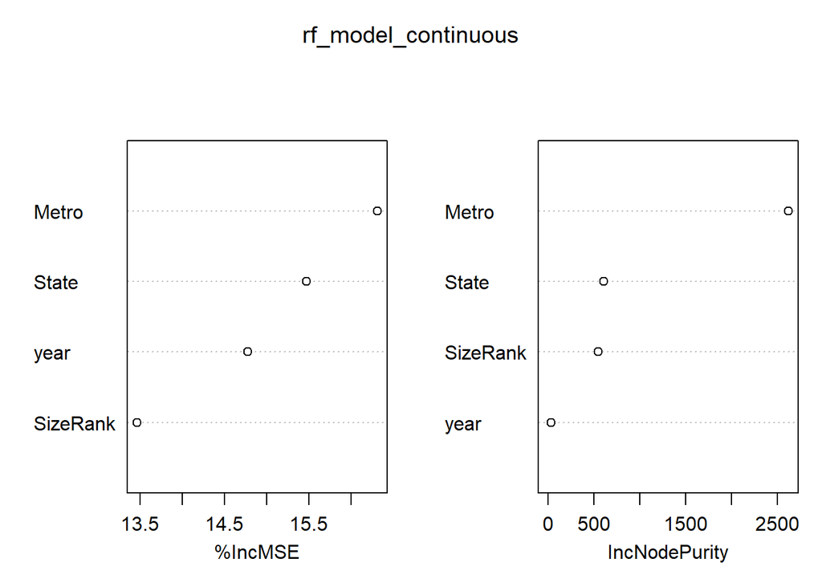

```r
varImpPlot(rf_model_continuous)
```

We observe from the random forest model explains slightly more of the variance compared to the linear regression model, but doesn’t really have better metrics in MAE or RMSE. We do observe that Metro and State are very important features in explaining log(ZHVI).

Similar to the other models, we observe that Metro, State, and Year having significant impacts on the model’s prediction power. Metro returning a significantly higher IncNodePurity than the rest. We’ve included both IncMSE and IncNodePurity plots. IncMSE explains the percentage increase in MSE is when said variable is excluded. As we can see they all have relatively high percentages(above 10%), but Metro has a gap between itself and the other variables.

What we can conclude from this is that again, housing data in the real world is very complex. Even in a model better suited for complex data, we weren’t really able to find the explanation in the variance of our target variable that we wanted at just 58%. Again, this ties back to how complex housing data can be and the many different variables that we don’t have access to via the Zillow dataset. Metrics like crime, avg size of homes in a given zip code. Or demographics like average income.

After much difficulty in developing a model with better predictive power, I decided to meet with Dr. Blumenthal at Gelman Library to learn how to merge new variables into the existing data we have. The two variables we will focus on is the number of houses in a given zipcode and the average income for a given zipcode. Dr. Blumenthal then gave me the follwing file called “Merged_ZHVI_ZCS.csv”. We will dive into the data below.

#Merging new variables into our current dataset#

```r
library(dplyr)
# Load the datasets
merged_zhvi_acs <- read.csv("Merged_ZHVI_ACS.csv")
colnames(housing_data)[colnames(housing_data) == "RegionName"] <-"Zipcode"
colnames(merged_zhvi_acs)[colnames(merged_zhvi_acs) == "zipcode"] <- "Zipcode"

# Check column names and preview data to find the common key
colnames(merged_zhvi_acs)
```

```
##  [1] "Zipcode"       "sizerank"      "state"         "metro"
##  [5] "city"          "zhvi"          "year"          "geoid"
##  [9] "name"          "averageincome" "incomemoe"     "households"
## [13] "householdmoe"
```

```r
colnames(housing_data)
```

```
##  [1] "RegionID"    "SizeRank"    "Zipcode"     "RegionType"  "State"
##  [6] "City"        "Metro"       "month"       "ZHVI"        "log_of_ZHVI"
## [11] "year"
```

```r
#Turn back to character for join
housing_data$Zipcode <- as.character(housing_data$Zipcode)
merged_zhvi_acs$Zipcode <- as.character(merged_zhvi_acs$Zipcode)


# Perform the left join
housing_data_updated <- housing_data %>%
  left_join(merged_zhvi_acs %>% select(Zipcode, averageincome, households),
            by = "Zipcode")
# Save the updated dataset
write.csv(housing_data_updated, "housingdata_updated.csv", row.names = FALSE)


# Check the summary of the updated dataset
summary(housing_data_updated)
```

```
##     RegionID         SizeRank       Zipcode           RegionType
##  Min.   : 66125   Min.   :   80   Length:86616       Length:86616
##  1st Qu.: 66825   1st Qu.: 6391   Class :character   Class :character
##  Median : 67339   Median :13358   Mode  :character   Mode  :character
##  Mean   : 67591   Mean   :13672
##  3rd Qu.: 67835   3rd Qu.:20293
##  Max.   :399556   Max.   :39992
##
##  State                  City
##  DC: 1584   Washington    : 1656
##  MD:30456   Baltimore     : 1440
##  VA:54576                 : 1080
##             Norfolk       :  864
##             Arlington     :  720
##             Virginia Beach:  648
##             (Other)       :80208
##                                           Metro          month
##  Washington-Arlington-Alexandria, DC-VA-MD-WV:22104   Length:86616
##                                              :18288   Class :character
##  Baltimore-Columbia-Towson, MD               :10584   Mode  :character
##  Richmond, VA                                : 6048
##  Virginia Beach-Norfolk-Newport News, VA-NC  : 5976
##  Charlottesville, VA                         : 2448
##  (Other)                                     :21168
##       ZHVI          log_of_ZHVI         year      averageincome
##  Min.   :  25919   Min.   :10.16   Min.   :2021   Min.   : 16375
##  1st Qu.: 209760   1st Qu.:12.25   1st Qu.:2021   1st Qu.: 57115
##  Median : 316930   Median :12.67   Median :2022   Median : 79167
##  Mean   : 358347   Mean   :12.62   Mean   :2022   Mean   : 88070
##  3rd Qu.: 448365   3rd Qu.:13.01   3rd Qu.:2023   3rd Qu.:109457
##  Max.   :2829491   Max.   :14.86   Max.   :2023   Max.   :250001
##  NA's   :2992      NA's   :2992                   NA's   :2556
##    households
##  Min.   :   19
##  1st Qu.:  599
##  Median : 1906
##  Mean   : 4874
##  3rd Qu.: 7618
##  Max.   :33351
##
```

We have merged data from ACS(American Community Survey) under the U.S. Census Bureau to bring in two new variables in our dataset. The variables we will be focusing on are the average household income(averageincome) in a given zipcode and the number of homes in a given zip code(households). Each of the variables aren’t monitored monthly like the ZHVI data we had. Another problem is that the variables only go up until 2022. The data for 2023 isn’t readily available yet at the time of writing.

The goal in adding these variables is for more of the variance in log(ZHVI) to be explained. From the context of housing as a topic, we know supply is said to have an impact on price as well as average household income.

Modeling should check if these variabels are statistically significant and if they have strong coefficneints/impacts on the target variable.

#New linear modeling with updated variables#

```r
housing_data_updated$log_of_ZHVI <- log(housing_data_updated$ZHVI)

#Check dataset
summary(housing_data_updated)
```

```
##     RegionID         SizeRank       Zipcode           RegionType
##  Min.   : 66125   Min.   :   80   Length:86616       Length:86616
##  1st Qu.: 66825   1st Qu.: 6391   Class :character   Class :character
##  Median : 67339   Median :13358   Mode  :character   Mode  :character
##  Mean   : 67591   Mean   :13672
##  3rd Qu.: 67835   3rd Qu.:20293
##  Max.   :399556   Max.   :39992
##
##  State                  City
##  DC: 1584   Washington    : 1656
##  MD:30456   Baltimore     : 1440
##  VA:54576                 : 1080
##             Norfolk       :  864
##             Arlington     :  720
##             Virginia Beach:  648
##             (Other)       :80208
##                                           Metro          month
##  Washington-Arlington-Alexandria, DC-VA-MD-WV:22104   Length:86616
##                                              :18288   Class :character
##  Baltimore-Columbia-Towson, MD               :10584   Mode  :character
##  Richmond, VA                                : 6048
##  Virginia Beach-Norfolk-Newport News, VA-NC  : 5976
##  Charlottesville, VA                         : 2448
##  (Other)                                     :21168
##       ZHVI          log_of_ZHVI         year      averageincome
##  Min.   :  25919   Min.   :10.16   Min.   :2021   Min.   : 16375
##  1st Qu.: 209760   1st Qu.:12.25   1st Qu.:2021   1st Qu.: 57115
##  Median : 316930   Median :12.67   Median :2022   Median : 79167
##  Mean   : 358347   Mean   :12.62   Mean   :2022   Mean   : 88070
##  3rd Qu.: 448365   3rd Qu.:13.01   3rd Qu.:2023   3rd Qu.:109457
##  Max.   :2829491   Max.   :14.86   Max.   :2023   Max.   :250001
##  NA's   :2992      NA's   :2992                   NA's   :2556
##    households
##  Min.   :   19
##  1st Qu.:  599
##  Median : 1906
##  Mean   : 4874
##  3rd Qu.: 7618
##  Max.   :33351
##
```

```r
#Building the new linear model with the two new variables from the merged data
new_housing_model <- lm(log_of_ZHVI ~ year+ averageincome + households + State + Metro + SizeRank, data = housing_data_updated)
summary(new_housing_model)
```

```
##
## Call:
## lm(formula = log_of_ZHVI ~ year + averageincome + households +
##     State + Metro + SizeRank, data = housing_data_updated)
##
## Residuals:
##      Min       1Q   Median       3Q      Max
## -1.75174 -0.14570  0.00781  0.15324  1.52114
##
## Coefficients:
##                                                     Estimate Std. Error t value
## (Intercept)                                       -1.012e+02  2.459e+00 -41.171
## year                                               5.600e-02  1.216e-03  46.041
## averageincome                                      8.448e-06  3.259e-08 259.215
## households                                        -1.394e-07  3.061e-07  -0.455
## StateMD                                           -2.930e-01  7.792e-03 -37.598
## StateVA                                           -2.835e-01  7.731e-03 -36.675
## MetroBaltimore-Columbia-Towson, MD                 2.854e-01  5.334e-03  53.509
## MetroBig Stone Gap, VA                            -6.342e-01  1.286e-02 -49.314
## MetroBlacksburg-Christiansburg, VA                 2.426e-02  8.313e-03   2.918
## MetroBluefield, WV-VA                             -4.028e-01  9.541e-03 -42.220
## MetroCalifornia-Lexington Park, MD                 2.172e-01  8.885e-03  24.446
## MetroCambridge, MD                                 1.721e-01  1.136e-02  15.145
## MetroCharlottesville, VA                           3.466e-01  6.275e-03  55.243
## MetroCumberland, MD-WV                            -2.467e-01  1.112e-02 -22.184
## MetroDanville, VA                                 -2.537e-01  8.785e-03 -28.885
## MetroEaston, MD                                    7.187e-01  1.055e-02  68.151
## MetroHagerstown-Martinsburg, MD-WV                 2.814e-01  9.700e-03  29.009
## MetroHarrisonburg, VA                              3.332e-01  9.358e-03  35.606
## MetroKingsport-Bristol, TN-VA                     -1.039e-01  8.929e-03 -11.638
## MetroLynchburg, VA                                 1.088e-01  6.978e-03  15.596
## MetroMartinsville, VA                             -4.981e-01  1.286e-02 -38.736
## MetroPhiladelphia-Camden-Wilmington, PA-NJ-DE-MD   2.980e-01  1.040e-02  28.653
## MetroRichmond, VA                                  2.316e-01  4.536e-03  51.052
## MetroRoanoke, VA                                   1.345e-01  6.554e-03  20.528
## MetroSalisbury, MD-DE                              8.905e-02  7.495e-03  11.882
## MetroStaunton, VA                                  2.816e-01  8.101e-03  34.759
## MetroVirginia Beach-Norfolk-Newport News, VA-NC    2.211e-01  4.582e-03  48.246
## MetroWashington-Arlington-Alexandria, DC-VA-MD-WV  4.464e-01  4.185e-03 106.662
## MetroWinchester, VA-WV                             4.241e-01  1.086e-02  39.058
```

[output cut: 24 more lines]

```
## MetroRichmond, VA                                  < 2e-16 ***
## MetroRoanoke, VA                                   < 2e-16 ***
## MetroSalisbury, MD-DE                              < 2e-16 ***
## MetroStaunton, VA                                  < 2e-16 ***
## MetroVirginia Beach-Norfolk-Newport News, VA-NC    < 2e-16 ***
## MetroWashington-Arlington-Alexandria, DC-VA-MD-WV  < 2e-16 ***
## MetroWinchester, VA-WV                             < 2e-16 ***
## SizeRank                                           < 2e-16 ***
## ---
## Signif. codes:  0 '***' 0.001 '**' 0.01 '*' 0.05 '.' 0.1 ' ' 1
##
## Residual standard error: 0.2832 on 81832 degrees of freedom
##   (4754 observations deleted due to missingness)
## Multiple R-squared:  0.7694, Adjusted R-squared:  0.7693
## F-statistic:  9414 on 29 and 81832 DF,  p-value: < 2.2e-16
```

Compared to the original linear model with only geographical predictors, this model is significantly improved. The Multiple R-squared is at 0.77 and the adjusted is the same. Now that we’ve come up with a linear regression model that’s more accurate, let’s dive into some of the coefficients.

Breaking down coefficients: A dollar increase in the average income corresponds to an increase in the log_ZHVI by about 0.0000084. This might seem insignificant, but it’s important since average household income increases are typically measured in thousands of dollars.

To no surprise coefficients for MD and VA are negative meaning they have a lower log_of_ZHVI compared to the reference state of DC. Specifically there’s a 25.4% decrease in ZHVI compared to the reference of DC. For virginia it’s actually 24.7% compared to DC. Holding all other variables constant.

SizeRank wasn’t a strong coefficient at all. A decrease in Sizerank value (number closer to 1), means log(ZHVI) decreases by 0.00029%

#Doing interaction terms with new model#

```r
interaction_model <- lm(log_of_ZHVI ~ averageincome * households + averageincome * State + averageincome * Metro + SizeRank, data = housing_data_updated)
summary(interaction_model)
```

```
##
## Call:
## lm(formula = log_of_ZHVI ~ averageincome * households + averageincome *
##     State + averageincome * Metro + SizeRank, data = housing_data_updated)
##
## Residuals:
##     Min      1Q  Median      3Q     Max
## -1.7905 -0.1427  0.0039  0.1497  1.3985
##
## Coefficients:
##                                                                   Estimate
## (Intercept)                                                      1.156e+01
## averageincome                                                    1.510e-05
## households                                                      -9.452e-06
## StateMD                                                         -6.502e-02
## StateVA                                                         -2.315e-01
## MetroBaltimore-Columbia-Towson, MD                               3.480e-01
## MetroBig Stone Gap, VA                                          -6.729e-01
## MetroBlacksburg-Christiansburg, VA                               5.193e-01
## MetroBluefield, WV-VA                                           -7.710e-01
## MetroCalifornia-Lexington Park, MD                               1.089e+00
## MetroCambridge, MD                                               7.168e-01
## MetroCharlottesville, VA                                         7.682e-01
## MetroCumberland, MD-WV                                           2.709e-01
## MetroDanville, VA                                                4.227e-01
## MetroEaston, MD                                                  1.142e+00
## MetroHagerstown-Martinsburg, MD-WV                               4.461e-01
## MetroHarrisonburg, VA                                            6.067e-01
## MetroKingsport-Bristol, TN-VA                                    2.660e-03
## MetroLynchburg, VA                                              -2.314e-01
## MetroMartinsville, VA                                           -1.096e-01
## MetroPhiladelphia-Camden-Wilmington, PA-NJ-DE-MD                 1.425e+00
## MetroRichmond, VA                                                6.275e-01
## MetroRoanoke, VA                                                 8.862e-02
## MetroSalisbury, MD-DE                                            5.366e-01
## MetroStaunton, VA                                                7.208e-01
## MetroVirginia Beach-Norfolk-Newport News, VA-NC                  5.784e-01
## MetroWashington-Arlington-Alexandria, DC-VA-MD-WV                1.063e+00
## MetroWinchester, VA-WV                                           1.219e+00
## SizeRank                                                        -3.782e-06
```

[output cut: 186 more lines]

```
## averageincome:MetroPhiladelphia-Camden-Wilmington, PA-NJ-DE-MD   < 2e-16 ***
## averageincome:MetroRichmond, VA                                  < 2e-16 ***
## averageincome:MetroRoanoke, VA                                  0.905935
## averageincome:MetroSalisbury, MD-DE                              < 2e-16 ***
## averageincome:MetroStaunton, VA                                  < 2e-16 ***
## averageincome:MetroVirginia Beach-Norfolk-Newport News, VA-NC    < 2e-16 ***
## averageincome:MetroWashington-Arlington-Alexandria, DC-VA-MD-WV  < 2e-16 ***
## averageincome:MetroWinchester, VA-WV                             < 2e-16 ***
## ---
## Signif. codes:  0 '***' 0.001 '**' 0.01 '*' 0.05 '.' 0.1 ' ' 1
##
## Residual standard error: 0.2709 on 81807 degrees of freedom
##   (4754 observations deleted due to missingness)
## Multiple R-squared:  0.789,  Adjusted R-squared:  0.7888
## F-statistic:  5664 on 54 and 81807 DF,  p-value: < 2.2e-16
```

The interaction term between averageincome and households is significant, with a p-value of less than 2e-16. This suggests that the relationship between average income and ZHVI may depend on the number of households.

The interaction term of average income and MD suggests the effect of average income isn’t as strongly positive as other states in our data. The interaction terms do have significace though given their p-values.

The multiple and adjusted r-squared are now 0.79. Now let’s test the model.

#Testing the same way with a scatterplot like the first simple model#

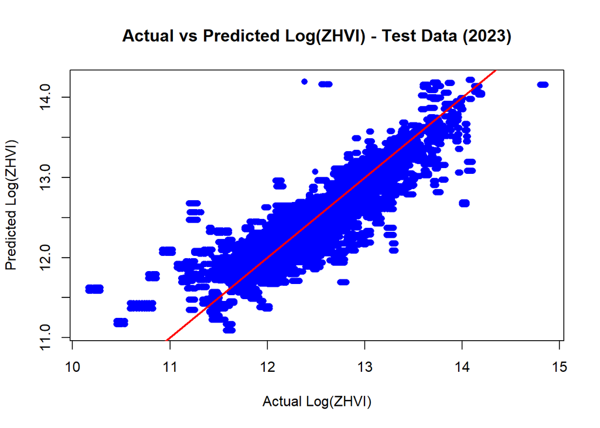

```r
# Split the data into training (2021-2022) and testing (2023)
training_data <- subset(housing_data_updated, year %in% c(2021, 2022))
testing_data <- subset(housing_data_updated, year == 2023)

# Fit the model on the training data
new_housing_model <- lm(log_of_ZHVI ~ averageincome * households + averageincome * State + averageincome * Metro + SizeRank, data = training_data)

# Predictions on testing data
predictions_new <- predict(new_housing_model, newdata = testing_data)

# Actual values from the testing data
actuals_new <- testing_data$log_of_ZHVI

# Plot Actual vs Predicted with 45-degree line
plot(actuals_new, predictions_new,
     xlab = "Actual Log(ZHVI)", ylab = "Predicted Log(ZHVI)",
     main = "Actual vs Predicted Log(ZHVI) - Test Data (2023)",
     pch = 16, col = "blue")

# Add the 45-degree line (perfect prediction)
abline(0, 1, col = "red", lwd = 2)  # 45-degree line for perfect predictions
```

#Tree modeling#

```r
#Using code we group the ZHVIs for each data together by regions/states, DC, MD, and VA


dc_data <- subset(housing_data, State == "DC")
summary(dc_data)
```

```
##     RegionID        SizeRank       Zipcode           RegionType        State
##  Min.   :66125   Min.   :  174   Length:792         Length:792         DC:792
##  1st Qu.:66130   1st Qu.: 1281   Class :character   Class :character   MD:  0
##  Median :66136   Median : 3792   Mode  :character   Mode  :character   VA:  0
##  Mean   :66137   Mean   : 5937
##  3rd Qu.:66142   3rd Qu.: 8424
##  Max.   :66155   Max.   :23188
##
##          City                                              Metro
##  Washington:792   Washington-Arlington-Alexandria, DC-VA-MD-WV:792
##            :  0                                               :  0
##  Abell     :  0   Baltimore-Columbia-Towson, MD               :  0
##  Aberdeen  :  0   Big Stone Gap, VA                           :  0
##  Abingdon  :  0   Blacksburg-Christiansburg, VA               :  0
##  Accident  :  0   Bluefield, WV-VA                            :  0
##  (Other)   :  0   (Other)                                     :  0
##     month                ZHVI          log_of_ZHVI         year
##  Length:792         Min.   : 249195   Min.   :12.43   Min.   :2021
##  Class :character   1st Qu.: 454537   1st Qu.:13.03   1st Qu.:2021
##  Mode  :character   Median : 594026   Median :13.29   Median :2022
##                     Mean   : 650863   Mean   :13.31   Mean   :2022
##                     3rd Qu.: 790203   3rd Qu.:13.58   3rd Qu.:2023
##                     Max.   :1343857   Max.   :14.11   Max.   :2023
##
```

```r
md_data <- subset(housing_data, State == "MD")
summary(md_data)
```

```
##     RegionID        SizeRank       Zipcode           RegionType
##  Min.   :66494   Min.   :  199   Length:15228       Length:15228
##  1st Qu.:66645   1st Qu.: 4985   Class :character   Class :character
##  Median :66802   Median :11963   Mode  :character   Mode  :character
##  Mean   :66803   Mean   :13070
##  3rd Qu.:66961   3rd Qu.:20373
##  Max.   :67111   Max.   :39992
##
##  State                 City
##  DC:    0   Baltimore    :  720
##  MD:15228                :  252
##  VA:    0   Silver Spring:  252
##             Laurel       :  180
##             Annapolis    :  144
##             Bowie        :  144
##             (Other)      :13536
##                                           Metro         month
##  Baltimore-Columbia-Towson, MD               :5292   Length:15228
##  Washington-Arlington-Alexandria, DC-VA-MD-WV:4824   Class :character
##  Salisbury, MD-DE                            :1080   Mode  :character
##                                              : 900
##  California-Lexington Park, MD               : 792
##  Hagerstown-Martinsburg, MD-WV               : 540
##  (Other)                                     :1800
##       ZHVI          log_of_ZHVI         year
##  Min.   :  52473   Min.   :10.87   Min.   :2021
##  1st Qu.: 294152   1st Qu.:12.59   1st Qu.:2021
##  Median : 395340   Median :12.89   Median :2022
##  Mean   : 420935   Mean   :12.84   Mean   :2022
##  3rd Qu.: 493668   3rd Qu.:13.11   3rd Qu.:2023
##  Max.   :2829491   Max.   :14.86   Max.   :2023
##  NA's   :468       NA's   :468
```

```r
va_data <- subset(housing_data, State == "VA")
summary(va_data)
```

```
##     RegionID         SizeRank       Zipcode           RegionType
##  Min.   : 66207   Min.   :   80   Length:27288       Length:27288
##  1st Qu.: 67380   1st Qu.: 7504   Class :character   Class :character
##  Median : 67702   Median :14464   Mode  :character   Mode  :character
##  Mean   : 68073   Mean   :14233
##  3rd Qu.: 68016   3rd Qu.:20456
##  Max.   :399556   Max.   :39992
##
##  State                  City
##  DC:    0   Norfolk       :  432
##  MD:    0   Arlington     :  360
##  VA:27288   Virginia Beach:  324
##                           :  288
##             Richmond      :  288
##             Roanoke       :  288
##             (Other)       :25308
##                                           Metro         month
##                                              :8244   Length:27288
##  Washington-Arlington-Alexandria, DC-VA-MD-WV:5436   Class :character
##  Richmond, VA                                :3024   Mode  :character
##  Virginia Beach-Norfolk-Newport News, VA-NC  :2988
##  Charlottesville, VA                         :1224
##  Roanoke, VA                                 :1080
##  (Other)                                     :5292
##       ZHVI          log_of_ZHVI         year
##  Min.   :  25919   Min.   :10.16   Min.   :2021
##  1st Qu.: 175627   1st Qu.:12.08   1st Qu.:2021
##  Median : 269728   Median :12.51   Median :2022
##  Mean   : 314345   Mean   :12.48   Mean   :2022
##  3rd Qu.: 384696   3rd Qu.:12.86   3rd Qu.:2023
##  Max.   :1477492   Max.   :14.21   Max.   :2023
##  NA's   :1028      NA's   :1028
```

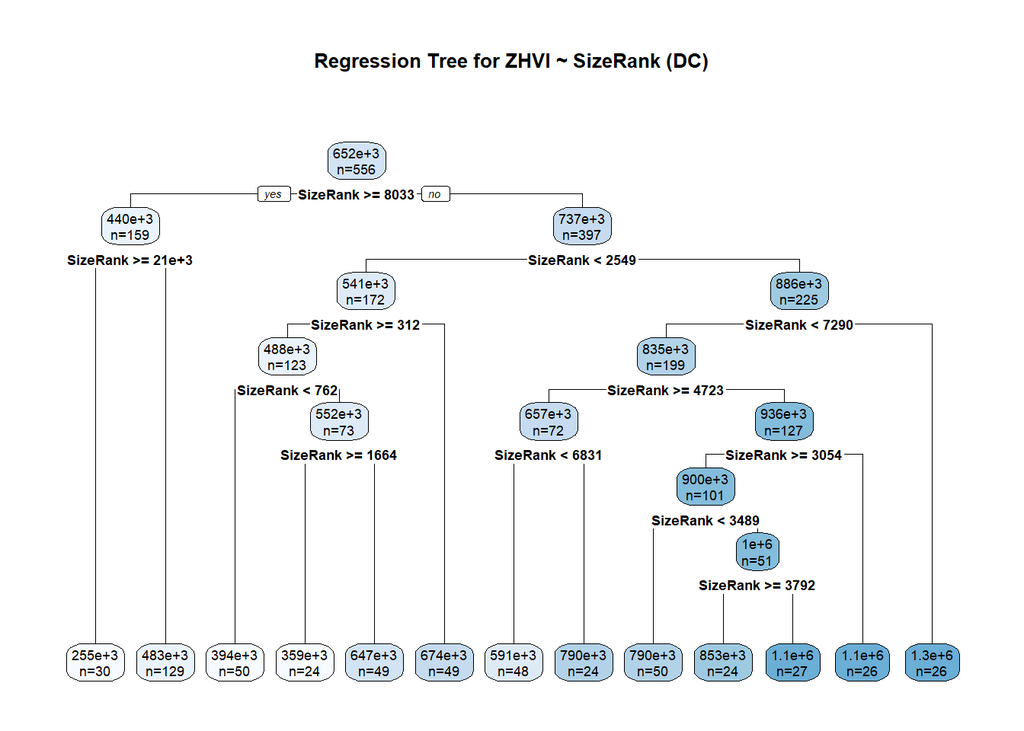

```r
library(rpart)
library(rpart.plot)
library(caret)
set.seed(123)
selected_columns <- c("SizeRank", "ZHVI")

train_index <- createDataPartition(dc_data$ZHVI, p = 0.7, list = FALSE)

train_data <- dc_data[train_index, selected_columns]
test_data <- dc_data[-train_index, selected_columns]

tree_model <- rpart(ZHVI ~ SizeRank, data = train_data, method = "anova")

rpart.plot(tree_model, type = 2, extra = 1, main = "Regression Tree for ZHVI ~ SizeRank (DC)")
```

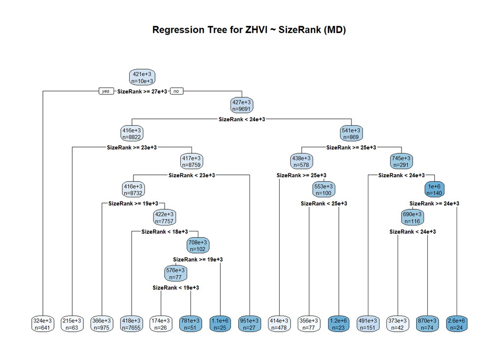

```r
set.seed(123)
md_data_clean <- na.omit(md_data[, c("SizeRank", "ZHVI")])
train_index1 <- createDataPartition(md_data_clean$ZHVI, p = 0.7, list = FALSE)

train_data1 <- md_data_clean[train_index1, selected_columns]
test_data1 <- md_data_clean[-train_index1, selected_columns]

tree_model1 <- rpart(ZHVI ~ SizeRank, data = train_data1, method = "anova")

rpart.plot(tree_model1, type = 2, extra = 1, main = "Regression Tree for ZHVI ~ SizeRank (MD)")
```

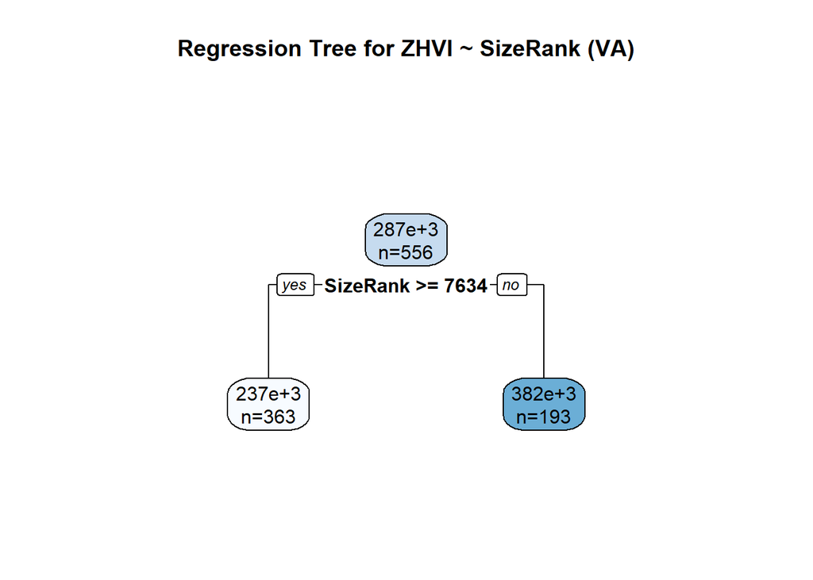

```r
set.seed(123)
va_data_clean <- na.omit(va_data[, c("SizeRank", "ZHVI")])
train_index2 <- createDataPartition(va_data_clean$ZHVI, p = 0.7, list = FALSE)

train_data2 <- va_data_clean[train_index, selected_columns]
test_data2 <- va_data_clean[-train_index, selected_columns]

tree_model2 <- rpart(ZHVI ~ SizeRank, data = train_data2, method = "anova")

rpart.plot(tree_model2, type = 2, extra = 1, main = "Regression Tree for ZHVI ~ SizeRank (VA)")
```

#Summarized write up and conclusion#

We decided to continue using the same dataset as we analyzed in our first project. This meant that the EDA was largely the same between both projects. Important pieces of EDA include evaluating the general trends of ZHVI prices across the different states from year to year. We saw a trend that DC on average had the highest housing prices, followed by Maryland and then Virginia. Housing prices also followed a similar trend between Virginia and Maryland, as there was an increase in average ZHVI value every year. D.C. had a bit of a different trend where it increased and then decreased. These EDA were important in getting an initial understanding of how the data behaves prior to any other more in-depth analysis done through building models.

Our SMART question was a bit of both inference and prediction. We acknowledge that home value/price data can be very complex in the real world with many factors holding varying influence over the given value of a home. The work we did modeling in this project is direct proof of this. Not only did we use the model to try and determine what exactly influences the value of Zillow home value, but we also tried to use the influences we found to test if we can build a model that can decently predict so. By taking our model and splitting training and testing data by certain years of our dataset we were able to see the predictive power of the model by comparing its results with our actual data for 2023. Our SMART questions also aimed to understand the current trends in the housing market by analyzing the data over the past 3 years.

There could be potential additional analysis that could be done in this study that would improve the analysis. The original dataset only included geographical information, which makes the study simple in its implementation. During the process of this project, we added other measures like number of households and average household income from other datasets to try to test certain non-geographical variables as well. This was a good starting point for understanding indicators of an increase or decrease in ZHVI. By adding different variables that would broaden the range of this study, it could be valuable in understanding why housing prices are increasing not just that they are increasing. This would also help with the limitation that this dataset only includes geographical data since it adds different types of data as well. This could also improve the model by further explaining trends in ZHVI changes. The data we added also has its limitations. As ACS data for 2023 wasn’t released yet. The model is pretty good and the results are quite reliable given the subject of our data, still non-geographic predictors like crime, sq feet, could improve it.

*References*

U.S. House Prices Rise 5.7 Percent over the Last Year; Up 0.9 Percent from the First Quarter of 2024 | FEDERAL HOUSING FINANCE AGENCY. (2024, August 27). FHFA.gov. https://www.fhfa.gov/news/news-release/u.s.-house-prices-rise-5.7-percent-over-the-last-year-up-0.9-percent-from-the-first-quarter-of-2024

US Census Bureau. (2021). American Community Survey (ACS). Census.gov. https://www.census.gov/programs-surveys/acs